# Лабораторная работа №6

Курс “Операционные Системы”

Лихтенштейн А.А., НКАбд-03-22

Российский университет дружбы народов, Москва, Россия

16 марта 2023

## Докладчик

- Лихтенштейн Алина Алексеевна
- студент группы НКАбд-03-22
- кафедры Компьютерные и информационные науки
- Российский университет дружбы народов
- 1132229533@pfur.ru

## Цели и задачи

**Целью работы** является ознакомление с инструментами поиска файлов и фильтрации текстовых данных. Приобретение практических навыков: по управлению процессами (и заданиями), по проверке использования диска и обслуживанию файловых систем.

**Задачи:**

1. Осуществим вход в систему, используя соответствующее имя пользователя.
2. Запишем в файл file.txt названия файлов, содержащихся в каталоге /etc. Допишем в этот же файл названия файлов, содержащихся в вашем домашнем каталоге.
3. Выведем имена всех файлов из file.txt, имеющих расширение .conf, после чего запишем их в новый текстовой файл conf.txt.
4. Определим, какие файлы в вашем домашнем каталоге имеют имена, начинавшиеся с символа c. Предложим несколько вариантов, как это сделать.
5. Выведем на экран (по странично) имена файлов из каталога /etc, начинающиеся с символа h.

## Цели и задачи

6. Запустим в фоновом режиме процесс, который будет записывать в файл ~/logfile файлы, имена которых начинаются с log.
7. Удалим файл ~/logfile.
8. Запустим из консоли в фоновом режиме редактор gedit.
9. Определим идентификатор процесса gedit, используя команду ps, конвейер и фильтр grep. Узнаем, как ещё можно определить идентификатор процесса.
10. Прочтем справку (man) команды kill, после чего используем её для завершения процесса gedit.
11. Выполним команды df и du, предварительно получив более подробную информацию об этих командах, с помощью команды man.
12. Воспользовавшись справкой команды find, выведем имена всех директорий, имеющихся в вашем домашнем каталоге.

# Выполнение лабораторной работы

## Задание 1

Осуществим вход в систему, используя соответствующее имя пользователя

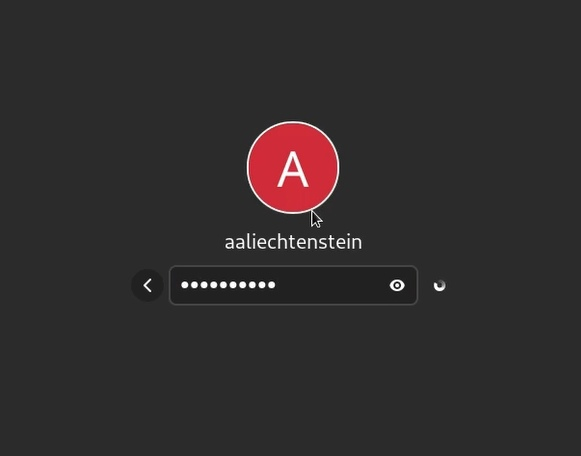

вход в систему

## Задание 2

Запишем в файл file.txt названия файлов, содержащихся в каталоге /etc. Допишем в этот же файл названия файлов, содержащихся в вашем домашнем каталоге

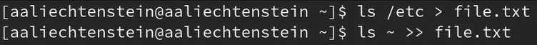

запись названий файлов в файл

## Задание 3

Выведем имена всех файлов из file.txt, имеющих расширение .conf, после чего запишем их в новый текстовой файл conf.txt

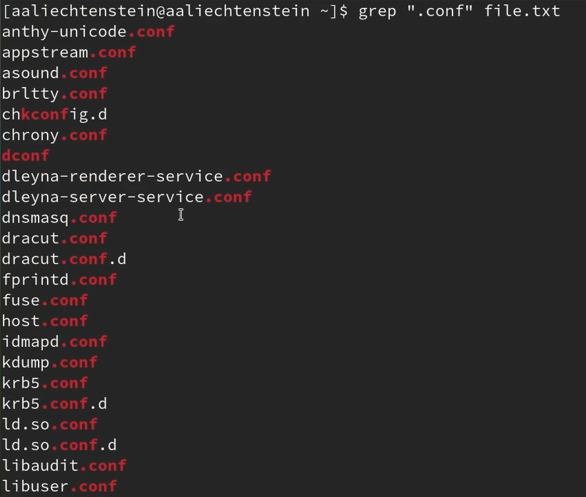

вывод имен файлов с расширением .conf

## Задание 3

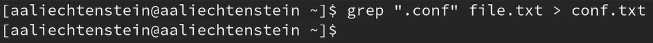

запись в новый текстовый файл

## Задание 4

Определим, какие файлы в вашем домашнем каталоге имеют имена, начинавшиеся с символа c. Предложим несколько вариантов, как это сделать

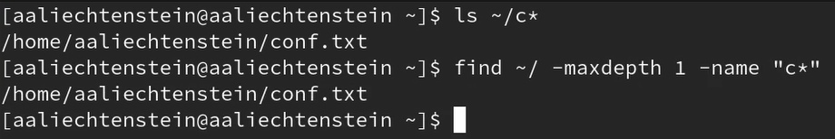

использование команд ls ~/C*, find ~/ -maxdepth 1 -name “c*”

## Задание 5

Выведем на экран (по странично) имена файлов из каталога /etc, начинающиеся с символа h

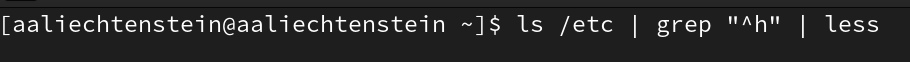

команда

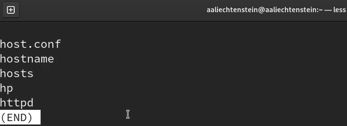

вывод команды

## Задание 6

Запустим в фоновом режиме процесс, который будет записывать в файл ~/logfile файлы, имена которых начинаются с log

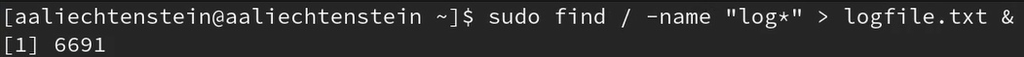

## Задание 8

Запустим из консоли в фоновом режиме редактор gedit

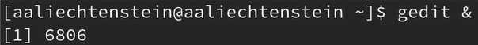

запуск gedit

## Задание 9

Определим идентификатор процесса gedit, используя команду ps, конвейер и фильтр grep. Узнаем, как ещё можно определить идентификатор процесса

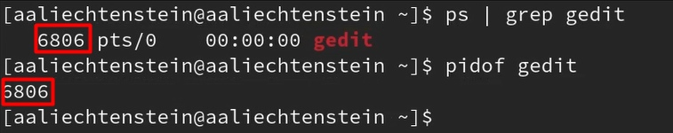

определение идентификатора процесса gedit

## Задание 10

Прочтем справку (man) команды kill, после чего используем её для завершения процесса gedit

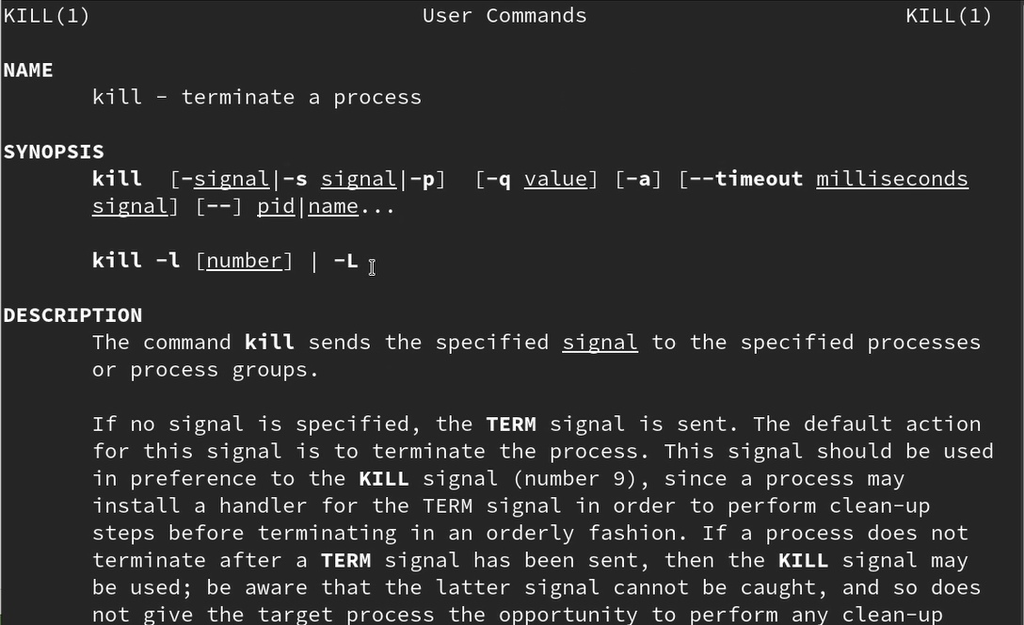

команда man kill

## Задание 10

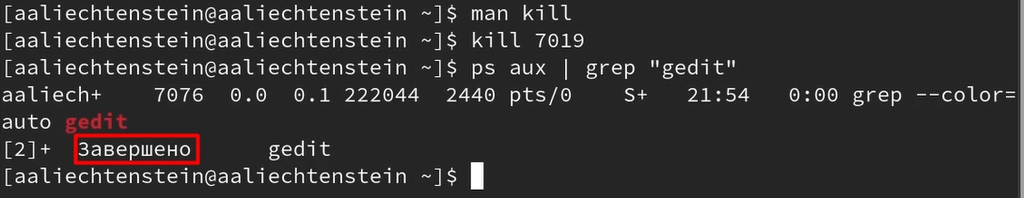

команда kill

## Задание 11

Выполним команды df и du, предварительно получив более подробную информацию об этих командах, с помощью команды man

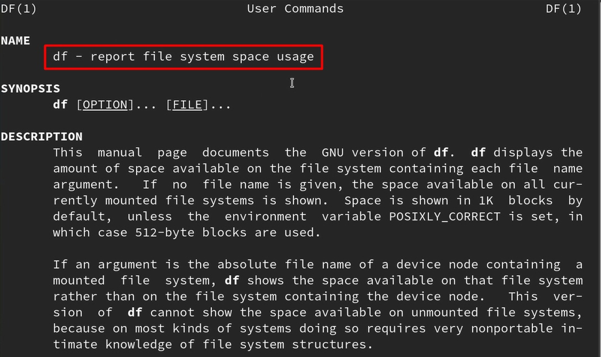

информация о команде df

## Задание 11

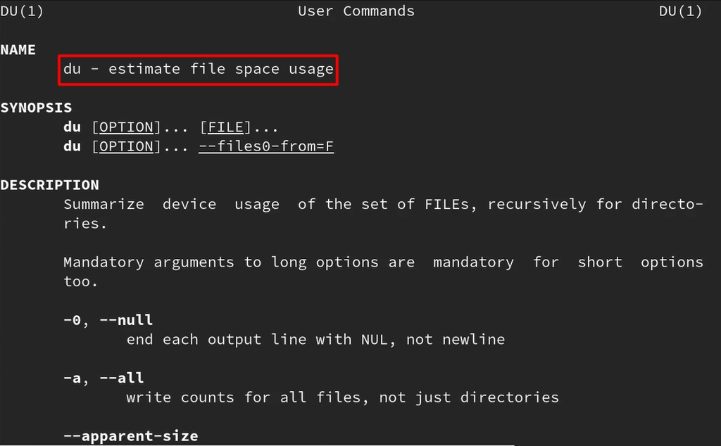

информация о команде du

## Задание 11

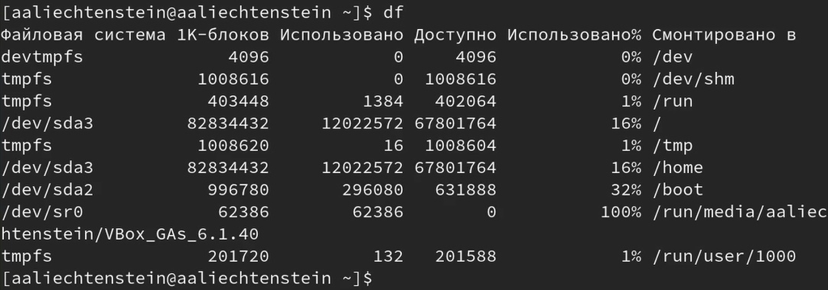

выполнение команды df

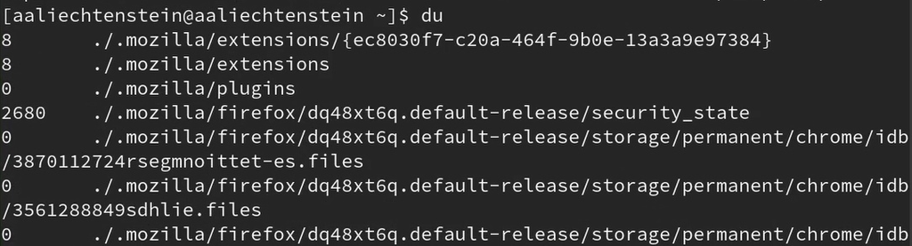

выполнение команды du

## Задание 12

Воспользовавшись справкой команды find, выведем имена всех директорий, имеющихся в нашем домашнем каталоге

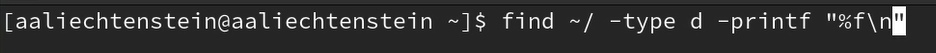

команда

## Задание 12

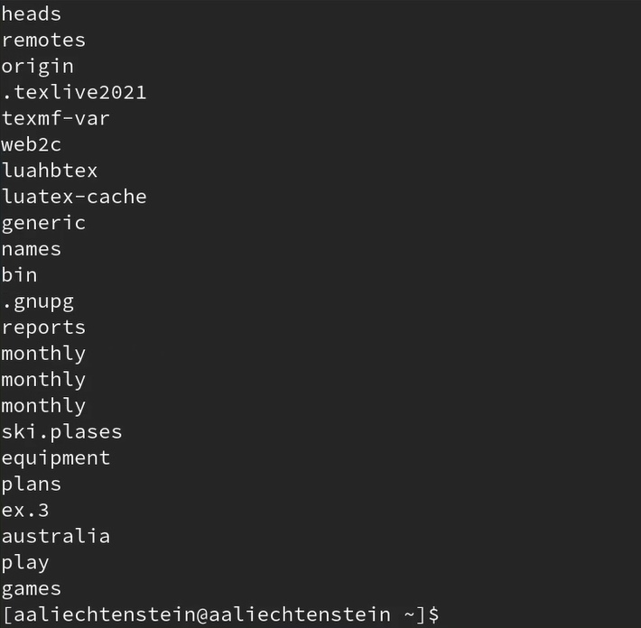

вывод команды

# Результаты

## Выводы

В процессе работы мы ознакомились с инструментами поиска файлов и фильтрации текстовых данных. Были приобретены практические навыки по управлению процессами (и заданиями), по проверке использования диска и обслуживанию файловых систем.